# Homework 2 Report

## Name

Ria Narayanan

### Setup

Read in the data with `read_csv()` and store the data as an R object named `dataset`. Check the data to make sure all of the expected observations and variables are there.

```r
## Load the data and any necessary packages here.
library(broom)
library(tidyverse)
dataset <- read_csv("maacs.csv.gz")
```

## Part 1

We will first consider the relationship between FEV1 and age. In general, it is expected that as children get older (and hence, larger in size), their FEV1 values should get higher.

Consider the statement “FEV1 values in children are higher in older children relative to younger children”.

Write a function in R that takes the `dataset` object as an argument and returns `TRUE` if the statement above is true for the dataset and `FALSE` otherwise.

NOTE: In order to write this function, you will need to translate the statement above into something that can be checked with the data. There are many ways in which you can do that translation correctly and you only need to pick one way here.

NOTE: For this part, do not use any plots.

```r
## Write your function here

check_fever <- function(dataset){
  d <- dataset %>%
    select(age, fev1) %>%
    drop_na()

  if (nrow(d) <10) return (FALSE)
  q <- quantile(d$age, probs = c(0.25, 0.75), na.rm = TRUE)
  younger <- d %>% filter(age <= q[1])
  older <- d %>% filter(age >= q[2])

  mean(older$fev1, na.rm = TRUE) > mean(younger$fev1, na.rm = TRUE)
}

check_fever(dataset)
```

```
## [1] TRUE
```

## Part 2

Fit a linear regression model with FEV1 as the outcome and age as a predictor.

How much does FEV1 change for a 1-year increase in the child’s age?

```r
## Add your code here

linear_regression_age <- lm(fev1 ~ age, data = dataset)
tidy(linear_regression_age, conf.int = TRUE)
```

```
## # A tibble: 2 × 7
##   term        estimate std.error statistic  p.value conf.low conf.high
##   <chr>          <dbl>     <dbl>     <dbl>    <dbl>    <dbl>     <dbl>
## 1 (Intercept) -0.00120    0.135   -0.00890 9.93e- 1   -0.268     0.265
## 2 age          0.171      0.0110  15.6     1.27e-31    0.149     0.193
```

```r
age_slope <- tidy(linear_regression_age) %>% filter(term == "age") %>% pull(estimate)
age_slope
```

```
## [1] 0.1711623
```

Write your data analysis statement interpreting the regression model here:

The model estimates that FEV1 increases by about .1711 liters for each 1-year increase in age. This supports the idea that older children, have higher FEV1 values than younger children.

## Part 3

Develop **three** supporting premises derived from the data that support the statement you wrote in Part 2. These can be plots, other summary statistics, or model results.

NOTE: At least one supporting premise should use a plot.

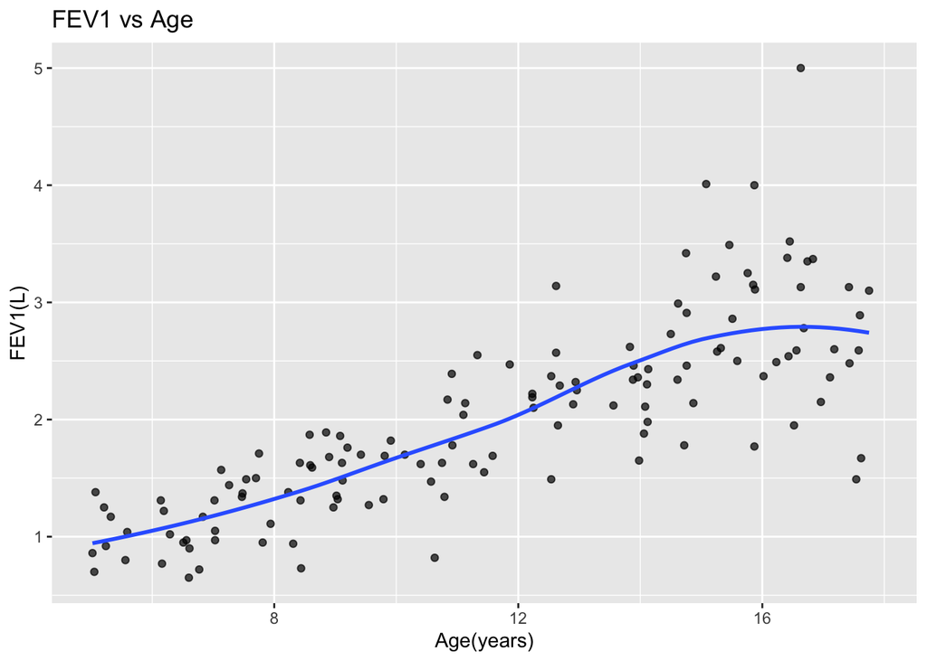

```r
## Add your code here

#premise 1)
scatterplot_premise <- ggplot(dataset, aes(x = age, y = fev1)) +
  geom_point(alpha = 0.7) +
  geom_smooth(se = FALSE) +
  labs(title = "FEV1 vs Age", x = "Age(years)",  y = "FEV1(L)")

scatterplot_premise
```

```r
#premise 2)
cor_test_pearson <- cor.test(dataset$age, dataset$fev1, use = "pairwise.complete.obs")
cor_test_spearman <- cor.test(dataset$fev1, dataset$fev1, use = "pairwise.complete.obs", method = "spearman")
cor_test_pearson
```

```
##
##  Pearson's product-moment correlation
##
## data:  dataset$age and dataset$fev1
## t = 15.583, df = 131, p-value < 2.2e-16
## alternative hypothesis: true correlation is not equal to 0
## 95 percent confidence interval:
##  0.7368348 0.8584229
## sample estimates:
##       cor
## 0.8059696
```

```r
cor_test_spearman
```

```
##
##  Spearman's rank correlation rho
##
## data:  dataset$fev1 and dataset$fev1
## S = 0, p-value < 2.2e-16
## alternative hypothesis: true rho is not equal to 0
## sample estimates:
## rho
##   1
```

```r
#premise 3)
q <- quantile(dataset$age, c(0.25, 0.75), na.rm = TRUE)
younger <- dataset %>% filter(age <= q[1])
older <- dataset %>% filter(age >= q[2])

mean_younger <- mean(younger$fev1, na.rm = TRUE)
mean_older <- mean(older$fev1, na.rm = TRUE)
diff <- mean_older - mean_younger
diff
```

```
## [1] 1.732382
```

1. The Scatterplot of FEV1 against age displays a positive, upward trend, indicating that older children tend to have higher FEV1 values than younger children. This confirms the initial conclusion.

3. From my quartile analysis, I found that children in the oldest quartile of age have an average FEV1 about 1.73 liters higher than children in the youngest quartile. This also supports the conclusion that FEV1 values are higher in older children than in younger children.

## Part 4

For each of the supporting premises above, write a function that takes the `dataset` object as an argument and returns `TRUE` if the supporting premise statement above is true for the dataset and `FALSE` otherwise.

For statements involving plots, instead of returning `TRUE` or `FALSE`, you function should do two things:

1. Produce the plot that is used in the statement
2. Produce a hypothetical version of the plot in the event that the statement is true. This can be done using simulated data or by simply hand drawing a plot.

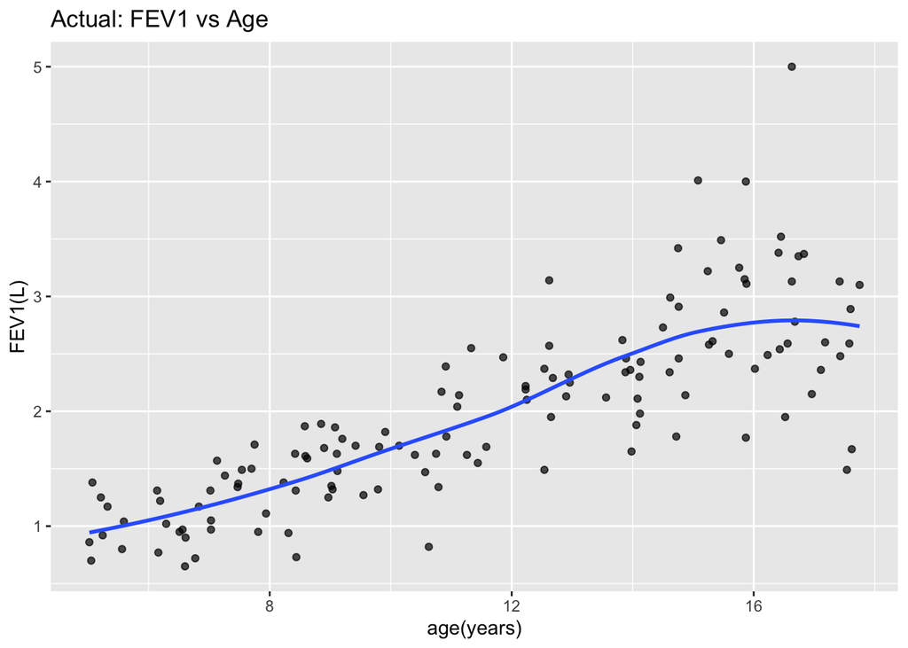

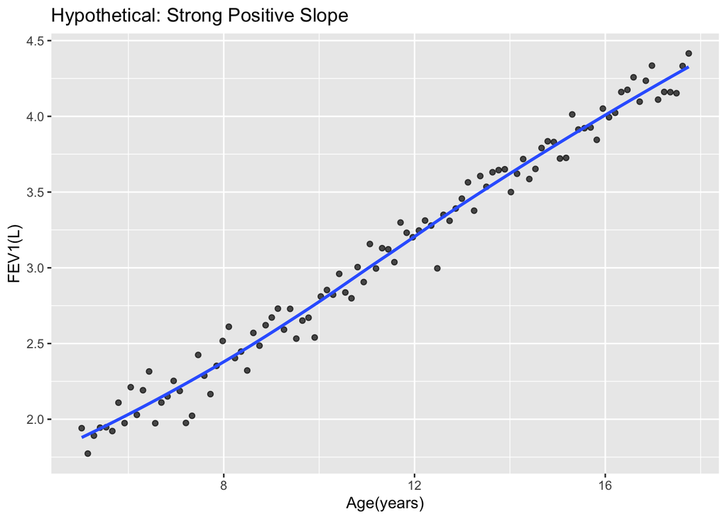

```r
## Function for supporting premise statement 1

premise1_plot <- function(dataset){
  d <- dataset %>% select(age, fev1) %>% drop_na()

  #actual plot
  p_actual <- ggplot(d, aes(x = age, y = fev1)) +
    geom_point(alpha = 0.7) +
    geom_smooth(se = FALSE) +
    labs(title = "Actual: FEV1 vs Age", x = "age(years)", y = "FEV1(L)")

  # hypothetical
  set.seed(42)
  sim <- tibble(
    age = seq(min(d$age), max(d$age), length.out = 100),
    fev1 = 0.8 +0.2 * seq(min(d$age), max(d$age), length.out = 100) +rnorm(100,0,0.1)
  )

  p_hyp <- ggplot(sim, aes(x = age, y = fev1)) +
    geom_point(alpha = 0.7) +
    geom_smooth(se = FALSE) +
    labs(title = "Hypothetical: Strong Positive Slope", x = "Age(years)", y = "FEV1(L)")

  print(p_actual)
  print(p_hyp)
}

premise1_plot(dataset)
```

```r
## Function for supporting premise statement 2

premise2_correlation<- function(dataset){
  d <- dataset %>% select(age, fev1) %>% drop_na()

  pearson <- cor.test(d$age, d$fev1, method = "pearson")
  spearman <- cor.test(d$age, d$fev1, method = "spearman")

  pearson$estimate > 0 & pearson$p.value < 0.05 &&
    spearman$estimate > 0 & spearman$p.value < 0.05
}
premise2_correlation(dataset)
```

```
## [1] TRUE
```

```r
## Function for supporting premise statement 3

premise3_quartile_diff <- function(dataset){
  d <- dataset %>% select(age, fev1) %>% drop_na()

  q <- quantile(d$age, c(0.25, 0.75), na.rm = TRUE)
  younger <- d %>% filter(age <= q[1])
  older <- d %>% filter(age>= q[2])

  mean_older <- mean(older$fev1, na.rm = TRUE)
  mean_younger <- mean(younger$fev1, na.rm = TRUE)
  mean_older > mean_younger


}

premise3_quartile_diff(dataset)
```

```
## [1] TRUE
```

Execute each of your function and show that the produce the expected output.

## Part 5

Describe one alternative to the primary statement “FEV1 values in children are higher in older children relative to younger children”.

Alternate Outcome: FEV1 values in children are the same in older children relative to younger children.

Create a fault tree for the alternative outcome describing how the alternative outcome could be realized in the data even if the primary statement were true.

Your fault tree should be created as a separate image and does not need to be created in R. Upload the image of the fault tree to Canvas.

Uploaded separately on Canvas